# IRT parameterization

Yuan-Ling Liaw

Item Response Theory is a comprehensive statistical framework that is used widely in educational and psychological research to model an examinee’s individual response patterns on a test or other instrument by specifying an interaction between the underlying latent trait and item characteristics.

A number of commercial software packages are available for the estimation of IRT models, such as Bilog-MG (Zimowski, Muraki, Mislevy, & Bock, 2006), Multilog (Thissen, 1991), Parscale (Muraki & Bock, 1997), ConQuest (Adams, Wu, & Wilson, 2012), IRTPRO (Cai, du Toit, & Thissen, 2011), and FlexMIRT (Cai, 2012). In recent years, some free IRT packages have been developed in the R environment (R Development Core Team, 2018), such as ltm (Rizopoulos, 2006), mirt (Chalmers, 2012), TAM (Robitzsch, Kiefer, & Wu, 2019), and sirt (Robitzsch, 2019). Many of these tools use different parameterizations of the model, making direct comparisons of results a challenge.

In this blog, we first demonstrate how to obtain comparable item parameter estimates in PARSCALE, mirt, TAM, for the two-parameter IRT model. Second, we demonstrate how to specify item parameters in order to generate response data in lsasim (Matta, Rutkowski, Rutkowski, & Liaw, 2018).

### Traditional IRT metric

In general, the logistic form of the two-parameter IRT model can be written as

$$p(y_{ij} = 1 | \theta_{j}) = \frac{1}
{1 + \text{exp} \left[ - Da_{i} (\theta_{j} - b_{i}) \right]}$$

where $y_{ij}$ is the response to item $i$ by respondent $j$, $\theta_{j}$ is the latent trait for respondent $j$, $D$ is a scaling constand ($D$ = 1.7 to scale the logistic to the normal ogive metric; $D$ = 1 to preserve the logistic metric), and $b_{i}$ and $a_{i}$ are the difficulty parameter and discrimination (slope) parameter, respectively, for item $i$.

When models are estimated in the logistic metric, which means that there is no $D$ = 1.7 scaling factor, $a_{i}$ discrimination (slope) parameters will be approximately 1.7 times higher than they would be if reported in the normal ogive metric.

Install R pacakges.

```r
library(mirt)
library(TAM)
library(lsasim)
```

```r
packageVersion("mirt")
```

```
[1] '1.30'
```

```r
packageVersion("TAM")
```

```
[1] '3.2.24'
```

```r
packageVersion("lsasim")
```

```
[1] '2.0.0.9016'
```

Load response data.

```r
resp <- read.csv2("C:\\resp.csv", header = F)
colnames(resp) <- c("id", "V1", "V2", "V3", "V4", "V5")
```

```r
head(resp)
```

```
  id V1 V2 V3 V4 V5
1  1  0  0  0  0  0
2  2  0  1  1  1  1
3  3  1  1  1  1  1
4  4  0  0  0  0  0
5  5  0  0  1  1  0
6  6  1  0  1  1  1
```

### The PARSCALE version

In the `PARSCALE` parameterization, $D$ can be set to either 1 or 1.7.

In the first command file, the scale constant is set to 1.

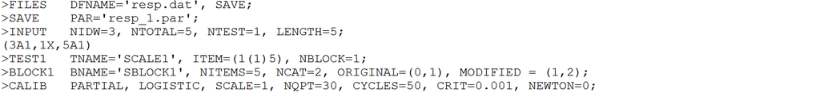

The output reported item parameters estimation in Phase 2, where $D$ = 1.

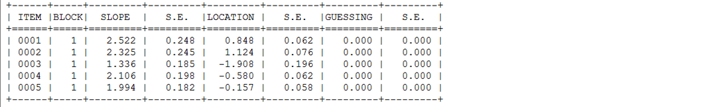

In the second command file, the scale constant is set to 1.7 for slope parameters.

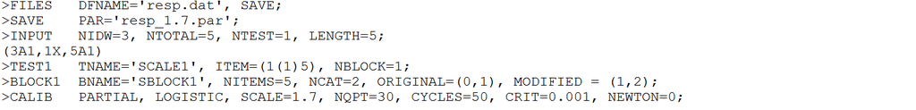

The output reported item parameters estimation in Phase 2, where $D$ = 1.7.

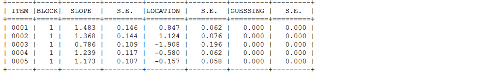

When models are estimated in the logistic metric ($D$ = 1), discrimination parameters are approximately 1.7 times higher than they reported in the normal ogive metric ($D$ = 1.7).

```r
slope_D1_logistic <- c(2.522, 2.325, 1.336, 2.106, 1.994)
slope_D1.7_normal <- c(1.483, 1.368, 0.786, 1.239, 1.173)
slope_D1_logistic/slope_D1.7_normal
```

```
[1] 1.700607 1.699561 1.699746 1.699758 1.699915
```

### The mirt version

In the `mirt` parameterization, the functions are written with the logistic metric, i.e., $a_{i}\theta_{j} + d_{i}$, where $d_{i}$ denotes item easiness. For the unidimensional models, the $d$ parameters can be converted into traditional IRT $b$ parameters. When `IRTpars = TRUE`, $b = -d/a$ while the $a$ parameters will be identical under this parameterization.

```r
mmirt <- mirt::mirt(resp[, paste0("V", 1:5)], 1, itemtype = "2PL", verbose = FALSE)
```

```r
mmirt_coef1 <- mirt::coef(mmirt, simplify = TRUE, IRTpars = FALSE)
mmirt_coef1$items
```

```
         a1          d g u
V1 2.522040 -2.1444262 0 1
V2 2.325332 -2.6195831 0 1
V3 1.335560  2.5464438 0 1
V4 2.103789  1.2154576 0 1
V5 1.991937  0.3083698 0 1
```

```r
mmirt_coef2 <- mirt::coef(mmirt, simplify = TRUE, IRTpars = TRUE)
mmirt_coef2$items
```

```
          a          b g u
V1 2.522040  0.8502744 0 1
V2 2.325332  1.1265417 0 1
V3 1.335560 -1.9066488 0 1
V4 2.103789 -0.5777469 0 1
V5 1.991937 -0.1548090 0 1
```

### The TAM version

In the `TAM` parameterization, the functions are written with the logistic metric in mind, i.e., $B_{i} \theta_{j} - xsi_{i}$, where $B$ represents item slopes and $xsi$ denotes item difficulties.

```r
mtam <- TAM::tam.mml.2pl(resp = resp[, paste0("V", 1:5)], irtmodel = "2PL", verbose = FALSE)
```

The first column shows $B$ item slopes and the second column shows $xsi$ item difficulties. $B$ are equivalent to traditional IRT $a$ parameters.

```r
cbind(mtam$B[1:5, 2, 1], mtam$xsi[, 1])
```

```
       [,1]       [,2]
V1 2.523893  2.1453010
V2 2.323765  2.6181900
V3 1.335626 -2.5465196
V4 2.104199 -1.2156551
V5 1.991855 -0.3084357
```

In order to get traditional IRT $b$ parameters, $xsi$ has to be divided by $B$.

```r
cbind(mtam$B[1:5, 2, 1], mtam$xsi[, 1]/mtam$B[1:5, 2, 1])
```

```
       [,1]       [,2]
V1 2.523893  0.8499967
V2 2.323765  1.1267017
V3 1.335626 -1.9066110
V4 2.104199 -0.5777281
V5 1.991855 -0.1548485
```

### The lsasim version

The functions of cognitive item responses generation are written with the logistic metric in the `lsasim`. $a_{i}$ and $b_{i}$ parameters in the traditional IRT metric are required when users want to specify item parameters.

Specify the number of subjects, the number of items, and the number of booklets.

```r
N <- 1000
I <- 5
K <- 1
```

Generate latent trait.

```r
theta <- rnorm(N, 0, 1)
```

Specify item parameters.

```r
item_pool <- data.frame(item = 1:I, b = c(0.85, 1.13, -1.91, -0.58, -0.15), a = c(2.52, 2.32,
    1.34, 2.1, 1.99), c = 0, k = 1, p = 2)
```

Specify rotated booklet design.

```r
block_bk1 <- lsasim::block_design(n_blocks = K, item_parameters = item_pool)

book_bk1 <- lsasim::booklet_design(item_block_assignment = block_bk1$block_assignment, book_design = matrix(K))

book_samp <- lsasim::booklet_sample(n_subj = N, book_item_design = book_bk1, book_prob = NULL)
```

Generate cognitive item response data.

```r
cog <- lsasim::response_gen(subject = book_samp$subject, item = book_samp$item, theta = theta,
    b_par = item_pool$b, a_par = item_pool$a)
```

```r
head(cog)
```

```
  i001 i002 i003 i004 i005 subject
1    0    0    0    0    0       1
2    1    0    1    1    1       2
3    0    0    1    1    0       3
4    0    0    1    1    1       4
5    0    0    1    1    0       5
6    1    0    1    1    1       6
```